## Course: Computational Thinking for Governance Analytics

### Prof. José Manuel Magallanes, PhD

# Session 7: Networks as Governance in R

Plan for this session:

1. Importing Data and Building a Network
2. Exploring Network
   - Network as a whole
   - Network communities
   - Network actors
3. Exporting the Network

The network we are going to build is based on a relationship studied in this paper:

[figure not shown]

In that paper, the researcher builds a matrix of relationships like this:

[figure not shown]

## 1. Importing Data

The data was not available from the author’s website, so the matrix you see above was copied and pasted to Excel. It looks like this:

[figure not shown]

The format of that data is an adjacency matrix, and the link to that file is here:

```r
# opening excel
library(rio)

linkAdjMx='https://github.com/EvansDataScience/CTforGA_Networks/raw/main/dataFigueroa.xlsx'

adjacency=import(linkAdjMx,which = 1)
```

This matrix is supposed to be squared. Is it?

```r
dim(adjacency)
```

```
## [1] 37 38
```

Take a look:

```r
head(adjacency)
```

```
##          Names Romero Grana Miro Quesada Moreyra Fort De La Puente Wiese
## 1       Romero      0     1            1       1    1            1     0
## 2        Grana      1     0            1       0    1            1     1
## 3 Miro Quesada      1     1            0       0    1            1     1
## 4      Moreyra      1     0            0       0    1            1     1
## 5         Fort      1     1            1       1    0            1     0
## 6 De La Puente      1     1            1       1    1            0     1
##   Onrubia Brescia Nicolini Montero Picaso Bentin Benavides Bustamante
## 1       1       1        1       0      0      1         1          1
## 2       0       0        0       1      0      0         1          1
## 3       0       0        0       1      0      0         1          1
## 4       1       1        0       1      1      1         0          1
## 5       1       1        1       0      1      1         1          1
## 6       0       0        0       1      0      0         1          1
##   Woodman Pollit Raffo Piazza Berckemeyer Llosa Barber Beoutis Ledesma
```

[output cut: 27 more lines]

The first column should be the row names:

```r
row.names(adjacency)=adjacency$Names
adjacency$Names=NULL

# then
adjacency
```

```
##                     Romero Grana Miro Quesada Moreyra Fort De La Puente Wiese
## Romero                   0     1            1       1    1            1     0
## Grana                    1     0            1       0    1            1     1
## Miro Quesada             1     1            0       0    1            1     1
## Moreyra                  1     0            0       0    1            1     1
## Fort                     1     1            1       1    0            1     0
## De La Puente             1     1            1       1    1            0     1
## Wiese                    0     1            1       1    0            1     0
## Onrubia                  1     0            0       1    1            0     0
## Brescia                  1     0            0       1    1            0     0
## Nicolini                 1     0            0       0    1            0     0
## Montero                  0     1            1       1    0            1     1
## Picaso                   0     0            0       1    1            0     0
## Bentin                   1     0            0       1    1            0     0
## Benavides                1     1            1       0    1            1     0
## Bustamante               1     1            1       1    1            1     0
## Woodman Pollit           1     0            0       0    1            0     0
## Raffo                    1     0            0       1    1            0     0
## Piazza                   1     1            1       0    1            1     0
## Berckemeyer              1     0            0       1    0            1     1
## Llosa Barber             1     0            0       0    1            0     0
## Beoutis Ledesma          0     1            1       0    1            1     1
## Rizo Patron              1     0            0       1    0            1     1
## Montori                  1     0            0       1    0            0     0
## Sotomayor                0     0            0       1    1            1     1
## Cilloniz                 0     0            0       0    1            0     0
## Ferreyros                0     0            0       0    0            0     0
## Michell                  0     1            1       0    0            0     0
## Wong Lu                  0     0            0       0    0            0     0
## Batievsky Spack          0     0            0       0    0            0     0
## Matos Escalada           0     0            0       0    0            0     0
## Galsky                   0     0            0       0    0            0     0
## Lucioni                  0     0            0       0    0            0     0
## Rodriguez Rodriguez      0     0            0       0    0            0     0
## Custer                   0     0            0       0    0            0     0
## Ikeda                    0     0            0       0    0            0     0
## Cogorno                  0     0            0       0    0            0     0
## Arias Davila             0     0            0       0    0            0     0
##                     Onrubia Brescia Nicolini Montero Picaso Bentin Benavides
## Romero                    1       1        1       0      0      1         1
```

[output cut: 211 more lines]

```
## Montori                 0       0            0
## Sotomayor               0       0            0
## Cilloniz                0       0            0
## Ferreyros               0       0            0
## Michell                 0       0            0
## Wong Lu                 0       0            0
## Batievsky Spack         0       0            0
## Matos Escalada          0       0            0
## Galsky                  0       0            0
## Lucioni                 0       0            0
## Rodriguez Rodriguez     0       0            0
## Custer                  0       0            0
## Ikeda                   0       0            0
## Cogorno                 0       0            0
## Arias Davila            0       0            0
```

This *data frame* has now to be converted into a **matrix**.

```r
adjacency=as.matrix(adjacency) # This coerces the object into a matrix, just in case
adjacency
```

```
##                     Romero Grana Miro Quesada Moreyra Fort De La Puente Wiese
## Romero                   0     1            1       1    1            1     0
## Grana                    1     0            1       0    1            1     1
## Miro Quesada             1     1            0       0    1            1     1
## Moreyra                  1     0            0       0    1            1     1
## Fort                     1     1            1       1    0            1     0
## De La Puente             1     1            1       1    1            0     1
## Wiese                    0     1            1       1    0            1     0
## Onrubia                  1     0            0       1    1            0     0
## Brescia                  1     0            0       1    1            0     0
## Nicolini                 1     0            0       0    1            0     0
## Montero                  0     1            1       1    0            1     1
## Picaso                   0     0            0       1    1            0     0
## Bentin                   1     0            0       1    1            0     0
## Benavides                1     1            1       0    1            1     0
## Bustamante               1     1            1       1    1            1     0
## Woodman Pollit           1     0            0       0    1            0     0
## Raffo                    1     0            0       1    1            0     0
## Piazza                   1     1            1       0    1            1     0
## Berckemeyer              1     0            0       1    0            1     1
## Llosa Barber             1     0            0       0    1            0     0
## Beoutis Ledesma          0     1            1       0    1            1     1
## Rizo Patron              1     0            0       1    0            1     1
## Montori                  1     0            0       1    0            0     0
## Sotomayor                0     0            0       1    1            1     1
## Cilloniz                 0     0            0       0    1            0     0
## Ferreyros                0     0            0       0    0            0     0
## Michell                  0     1            1       0    0            0     0
## Wong Lu                  0     0            0       0    0            0     0
## Batievsky Spack          0     0            0       0    0            0     0
## Matos Escalada           0     0            0       0    0            0     0
## Galsky                   0     0            0       0    0            0     0
## Lucioni                  0     0            0       0    0            0     0
## Rodriguez Rodriguez      0     0            0       0    0            0     0
## Custer                   0     0            0       0    0            0     0
## Ikeda                    0     0            0       0    0            0     0
## Cogorno                  0     0            0       0    0            0     0
## Arias Davila             0     0            0       0    0            0     0
##                     Onrubia Brescia Nicolini Montero Picaso Bentin Benavides
## Romero                    1       1        1       0      0      1         1
```

[output cut: 211 more lines]

```
## Montori                 0       0            0
## Sotomayor               0       0            0
## Cilloniz                0       0            0
## Ferreyros               0       0            0
## Michell                 0       0            0
## Wong Lu                 0       0            0
## Batievsky Spack         0       0            0
## Matos Escalada          0       0            0
## Galsky                  0       0            0
## Lucioni                 0       0            0
## Rodriguez Rodriguez     0       0            0
## Custer                  0       0            0
## Ikeda                   0       0            0
## Cogorno                 0       0            0
## Arias Davila            0       0            0
```

From this kind of structure (the adjacency *matrix*), we can easily create a network via **Igraph**:

```r
library(igraph)
EliteNet=graph.adjacency(adjacency,mode="undirected",weighted=NULL)
# see it here
EliteNet
```

```
## IGRAPH 51cb018 UN-- 37 135 --
## + attr: name (v/c)
## + edges from 51cb018 (vertex names):
##  [1] Romero--Grana          Romero--Miro Quesada   Romero--Moreyra
##  [4] Romero--Fort           Romero--De La Puente   Romero--Onrubia
##  [7] Romero--Brescia        Romero--Nicolini       Romero--Bentin
## [10] Romero--Benavides      Romero--Bustamante     Romero--Woodman Pollit
## [13] Romero--Raffo          Romero--Piazza         Romero--Berckemeyer
## [16] Romero--Llosa Barber   Romero--Rizo Patron    Romero--Montori
## [19] Grana --Miro Quesada   Grana --Fort           Grana --De La Puente
## [22] Grana --Wiese          Grana --Montero        Grana --Benavides
## + ... omitted several edges
```

A network is composed of *nodes* (aka vertices) and *edges* that connect them. You can know how many you have of each like this:

```r
vcount(EliteNet) #count of nodes
```

```
## [1] 37
```

```r
ecount(EliteNet) #count of edges
```

```
## [1] 135
```

You can take a look at how this network looks like:

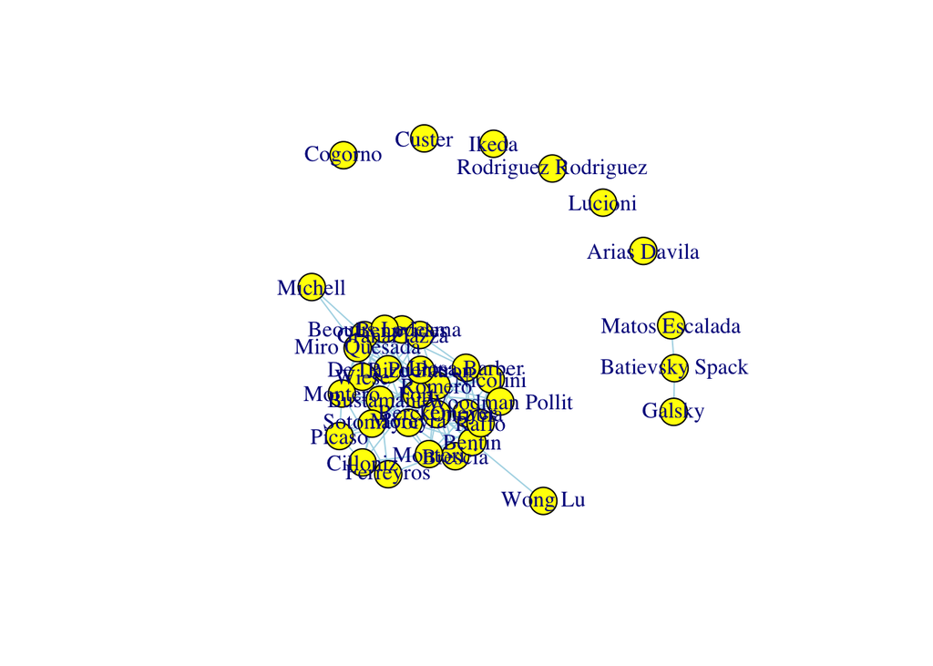

```r
plot.igraph(EliteNet,
            vertex.color = 'yellow',
            edge.color='lightblue')
```

So far we only have nodes and their links. Let’s bring som information about the nodes:

```r
# The adjacency matrix did not include the nodes attributes.
attributes=import(linkAdjMx,which = 2)
head(attributes)
```

```
##          Nodes multinational
## 1       Romero             1
## 2        Grana             1
## 3 Miro Quesada             1
## 4      Moreyra             1
## 5         Fort             1
## 6 De La Puente             1
```

Igraph can add an attribute easily. Let’s proceed with the change:

```r
EliteNet=set_vertex_attr(EliteNet,"multi",value=attributes$multinational)

#then
EliteNet
```

```
## IGRAPH 51cb018 UN-- 37 135 --
## + attr: name (v/c), multi (v/n)
## + edges from 51cb018 (vertex names):
##  [1] Romero--Grana          Romero--Miro Quesada   Romero--Moreyra
##  [4] Romero--Fort           Romero--De La Puente   Romero--Onrubia
##  [7] Romero--Brescia        Romero--Nicolini       Romero--Bentin
## [10] Romero--Benavides      Romero--Bustamante     Romero--Woodman Pollit
## [13] Romero--Raffo          Romero--Piazza         Romero--Berckemeyer
## [16] Romero--Llosa Barber   Romero--Rizo Patron    Romero--Montori
## [19] Grana --Miro Quesada   Grana --Fort           Grana --De La Puente
## [22] Grana --Wiese          Grana --Montero        Grana --Benavides
## + ... omitted several edges
```

It should have worked:

```r
vertex_attr_names(EliteNet)
```

```
## [1] "name"  "multi"
```

Before going further, it is good to know if our network is connected:

```r
is_connected(EliteNet)
```

```
## [1] FALSE
```

So we have these people in components, how many?

```r
components(EliteNet)$no
```

```
## [1] 8
```

What nodes are in each component?:

```r
groups(components(EliteNet))
```

```
## $`1`
##  [1] "Romero"          "Grana"           "Miro Quesada"    "Moreyra"
##  [5] "Fort"            "De La Puente"    "Wiese"           "Onrubia"
##  [9] "Brescia"         "Nicolini"        "Montero"         "Picaso"
## [13] "Bentin"          "Benavides"       "Bustamante"      "Woodman Pollit"
## [17] "Raffo"           "Piazza"          "Berckemeyer"     "Llosa Barber"
## [21] "Beoutis Ledesma" "Rizo Patron"     "Montori"         "Sotomayor"
## [25] "Cilloniz"        "Ferreyros"       "Michell"         "Wong Lu"
##
## $`2`
## [1] "Batievsky Spack" "Matos Escalada"  "Galsky"
##
## $`3`
## [1] "Lucioni"
##
## $`4`
## [1] "Rodriguez Rodriguez"
##
## $`5`
## [1] "Custer"
##
## $`6`
## [1] "Ikeda"
##
## $`7`
## [1] "Cogorno"
##
## $`8`
## [1] "Arias Davila"
```

Let me add the component as an attribute:

```r
component=components(EliteNet)$membership
EliteNet=set_vertex_attr(EliteNet,"component",value=component)
#then
EliteNet
```

```
## IGRAPH 51cb018 UN-- 37 135 --
## + attr: name (v/c), multi (v/n), component (v/n)
## + edges from 51cb018 (vertex names):
##  [1] Romero--Grana          Romero--Miro Quesada   Romero--Moreyra
##  [4] Romero--Fort           Romero--De La Puente   Romero--Onrubia
##  [7] Romero--Brescia        Romero--Nicolini       Romero--Bentin
## [10] Romero--Benavides      Romero--Bustamante     Romero--Woodman Pollit
## [13] Romero--Raffo          Romero--Piazza         Romero--Berckemeyer
## [16] Romero--Llosa Barber   Romero--Rizo Patron    Romero--Montori
## [19] Grana --Miro Quesada   Grana --Fort           Grana --De La Puente
## [22] Grana --Wiese          Grana --Montero        Grana --Benavides
## + ... omitted several edges
```

A visual representation follows:

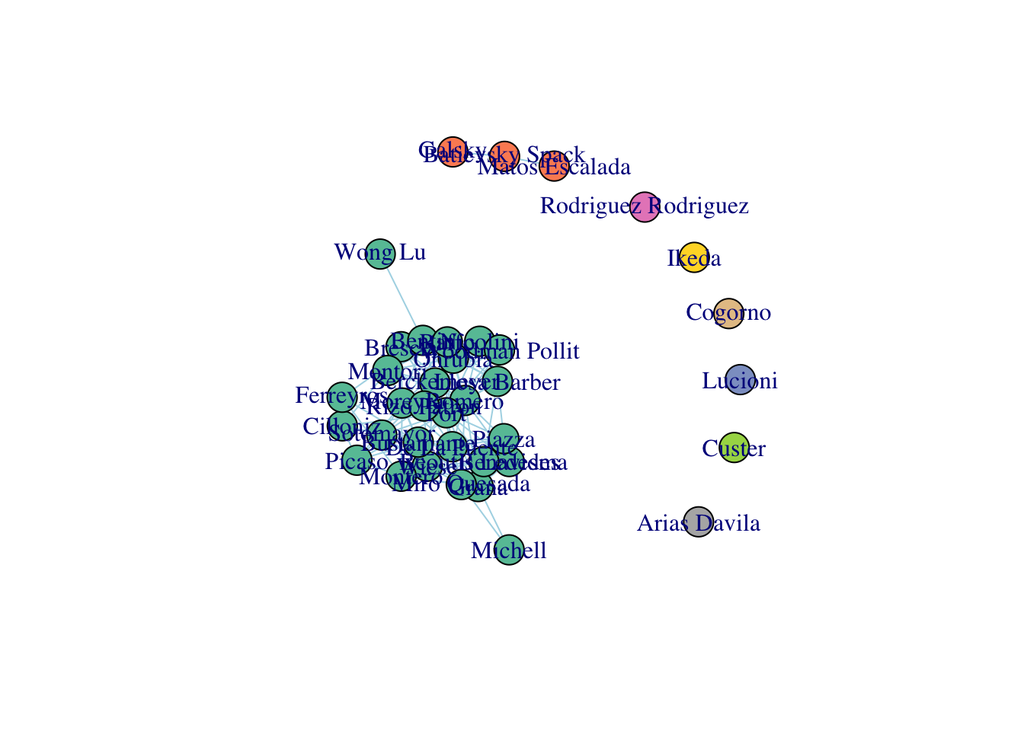

```r
Labels=component
numberOfClasses = length(unique(Labels))

#preparing color
library(RColorBrewer)
colorForScale='Set2'
colors = brewer.pal(numberOfClasses, colorForScale)

# plotting
plot.igraph(EliteNet,
             vertex.color = colors[Labels],
             edge.color='lightblue')
```

As we do not have ONE connected network but several components, we can pay attention to the Giant Component (component with max nodes), follow these steps:

1. Get the sizes of each component:

```r
(Sizes=components(EliteNet)$csize)
```

```
## [1] 28  3  1  1  1  1  1  1
```

2. Get the subnet with the largest component:

```r
# this is a subnet
EliteNet_giant=induced.subgraph(EliteNet, which(Labels == which.max(Sizes)))
```

Let’s take a look at the Giant Component:

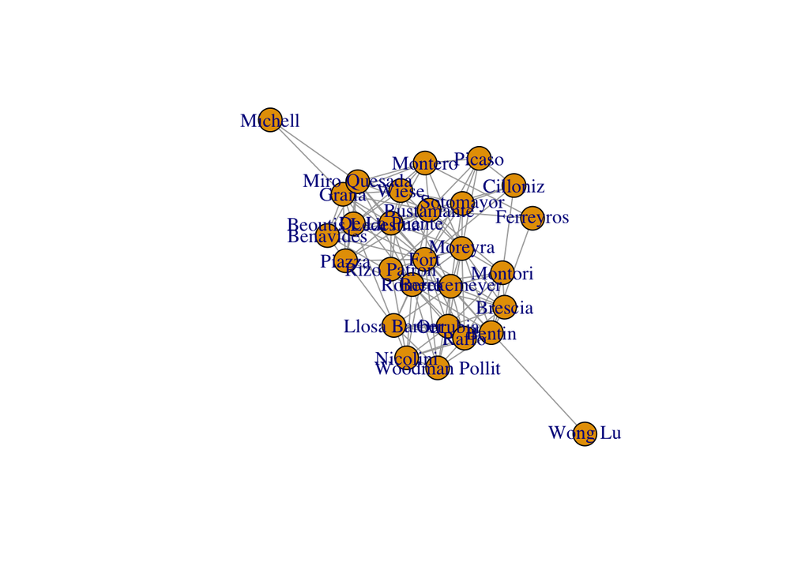

```r
plot.igraph(EliteNet_giant)
```

Basic summary:

```r
summary(EliteNet_giant)
```

```
## IGRAPH af6d51c UN-- 28 133 --
## + attr: name (v/c), multi (v/n), component (v/n)
```

We will use the giant component as our network to be explored. ____

## 2. Exploring the NETWORK

### Exploring the Network as a whole

- Density: from 0 to 1, where 1 makes it a ‘complete’ network: there is a link between every pair of nodes.

[figure not shown]

```r
graph.density(EliteNet_giant)
```

```
## [1] 0.3518519
```

- Diameter: worst case escenario for number of steps for someone to contact another one (only for connected component).

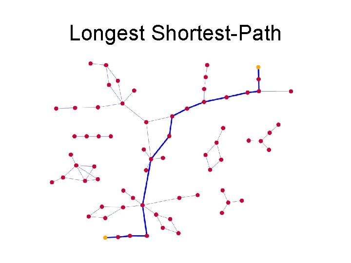

```r
diameter(EliteNet_giant)
```

```
## [1] 4
```

- Local clustering coefficient of a node is away to measure the level of connectivity its neighbors. If all its neighbors are connected among one another you get 1; if none of them is connected you get zero. Then, the average clustering coefficient tells you the average of those values.

```r
# we need some help beyond Igraph:
transitivity(EliteNet_giant,type = 'average')
```

```
## [1] 0.6537019
```

- Shortest path (average): it gets the average of every shortest path among the nodes in the network. A shorter path is the shortest *walk* from one node to another.

```r
average.path.length(EliteNet_giant)
```

```
## [1] 1.740741
```

**Random networks** have *small shortest path* and *small clustering coefficient*…Is this the case?. The high clustering coefficient would suggest a **small world**, as most nodes are not neighbors of one another, but most nodes can be reached from every other in few steps.

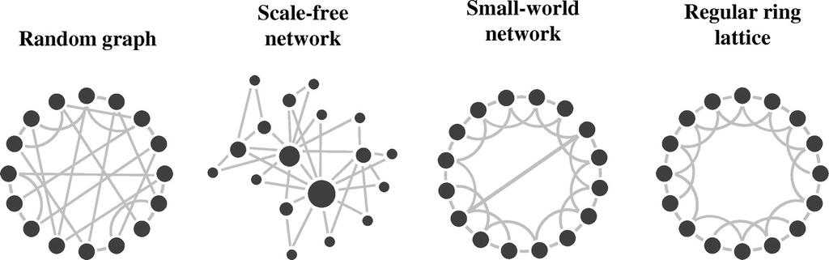

- Transitivity: How probable is that two business men with a common business friend, are also friends.

```r
transitivity(EliteNet_giant)
```

```
## [1] 0.5829694
```

- Assortativity (degree): it is a measure to see if nodes are connecting to other nodes similar in degree. Closer to 1 means higher assortativity, closer to -1 diassortativity; while 0 is no assortitivity.

```r
assortativity_degree(EliteNet_giant)
```

```
## [1] -0.1208671
```

You can also compute assortativity using an attribute of interest:

```r
attrNet=V(EliteNet_giant)$multi
assortativity(EliteNet_giant,attrNet)
```

```
## [1] -0.07258065
```

Coloring by attribute:

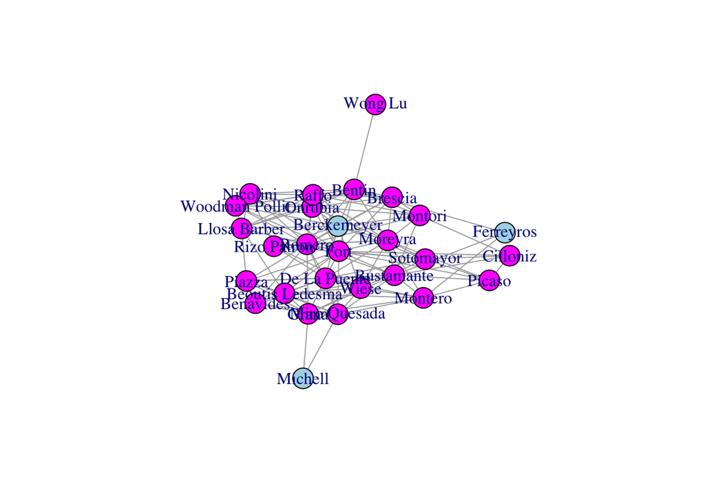

```r
LabelsColor=attrNet+1
colors=c('lightblue','magenta')
plot.igraph(EliteNet_giant,
       vertex.color = colors[LabelsColor])
```

### Exploration of network communities

A **clique** can be understood a community of nodes where all of them are connected to one another.

- How many cliques can be found in this network?

```r
length(cliques(EliteNet_giant))
```

```
## [1] 1074
```

If a clique in the network can not be bigger is you add another node, then you have a **maximal clique**.

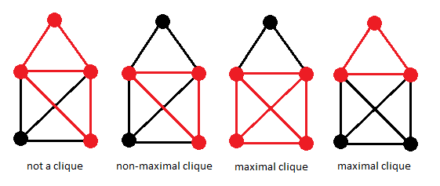

- How many maximal cliques are there in this network?

```r
# How many cliques
count_max_cliques(EliteNet_giant)
```

```
## [1] 28
```

You can find the size of the *maximum cliques*:

```r
clique_num(EliteNet_giant)
```

```
## [1] 8
```

You can see each maximum clique like this:

```r
max_cliques(EliteNet_giant,min=8)
```

```
## [[1]]
## + 8/28 vertices, named, from af6d51c:
## [1] Onrubia        Romero         Raffo          Bentin         Fort
## [6] Llosa Barber   Woodman Pollit Nicolini
##
## [[2]]
## + 8/28 vertices, named, from af6d51c:
## [1] Onrubia     Romero      Raffo       Bentin      Berckemeyer Montori
## [7] Brescia     Moreyra
##
## [[3]]
## + 8/28 vertices, named, from af6d51c:
## [1] Benavides    Romero       Piazza       Bustamante   De La Puente
## [6] Fort         Miro Quesada Grana
```

If a network presents cliques makes you suspect that there can be **communities**.

This is a huge field of research, let me me show you one of the algorithms known as the [*Louvain method*](https://perso.uclouvain.be/vincent.blondel/research/louvain.html).

```r
communities=cluster_louvain(EliteNet_giant)
(partition=membership(communities))
```

```
##          Romero           Grana    Miro Quesada         Moreyra            Fort
##               1               2               2               3               2
##    De La Puente           Wiese         Onrubia         Brescia        Nicolini
##               2               3               1               1               1
##         Montero          Picaso          Bentin       Benavides      Bustamante
##               2               3               1               2               2
##  Woodman Pollit           Raffo          Piazza     Berckemeyer    Llosa Barber
##               1               1               2               1               1
## Beoutis Ledesma     Rizo Patron         Montori       Sotomayor        Cilloniz
##               2               3               1               3               3
##       Ferreyros         Michell         Wong Lu
##               2               2               1
```

Now, use those values to make a plot to highlight the communities:

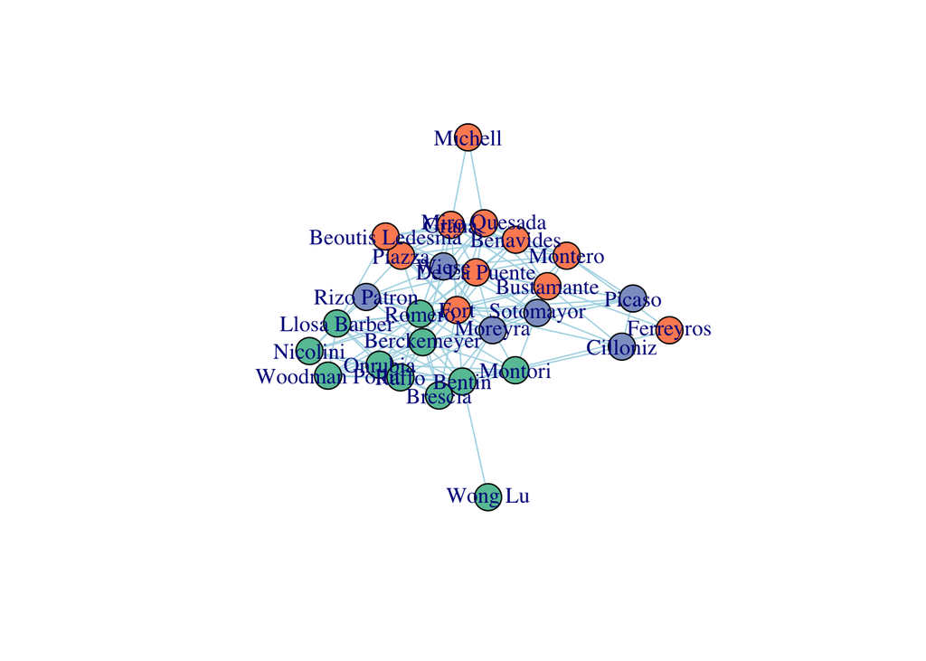

```r
Labels=partition
numberOfClasses = length(unique(Labels))

library(RColorBrewer)
colorForScale='Set2'
colors = brewer.pal(numberOfClasses, colorForScale)

plot.igraph(EliteNet_giant,
             vertex.color = colors[Labels],
             edge.color='lightblue')
```

Let’s turn our attention to the nodes and their roles in the network.

### Exploration of network actors

```r
rounding=3
degr=round(degree(EliteNet_giant,,normalized=T),rounding)
close=round(closeness(EliteNet_giant,,normalized=T),rounding)
betw=round(betweenness(EliteNet_giant,,normalized=T),rounding)

DFCentrality=as.data.frame(cbind(degr,close,betw),stringsAsFactors = F)
names(DFCentrality)=c('Degree','Closeness','Betweenness')
```

```r
DFCentrality$person=row.names(DFCentrality)
row.names(DFCentrality)=NULL
head(DFCentrality)
```

```
##   Degree Closeness Betweenness       person
## 1  0.667     0.750       0.102       Romero
## 2  0.407     0.614       0.043        Grana
## 3  0.407     0.614       0.043 Miro Quesada
## 4  0.556     0.675       0.066      Moreyra
## 5  0.704     0.771       0.155         Fort
## 6  0.519     0.659       0.039 De La Puente
```

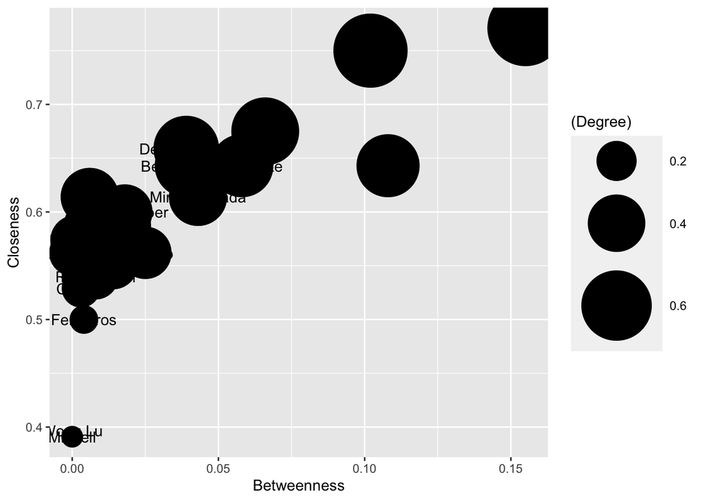

```r
library(ggplot2)
ggplot(DFCentrality, aes(x=Betweenness, y=Closeness)) +
  geom_point(aes(size=(Degree))) +
  scale_colour_gradient(low = "yellow", high = "red") +
  scale_size(range = c(1, 25))  + geom_text(label=DFCentrality$person)
```

The node with the highest degree could be considered a *hub* in the network:

```r
DFCentrality[which.max(DFCentrality$Degree),]
```

```
##   Degree Closeness Betweenness person
## 5  0.704     0.771       0.155   Fort
```

We can plot the neighbors of the hub, *its ego network*:

1. Determine the hub name:

```r
#who
hub=DFCentrality[which.max(DFCentrality$Degree),]$person
```

2. Determine the hub position:

```r
#where (a character to numeric)
hubix=as.numeric(row.names(DFCentrality[which.max(DFCentrality$Degree),]))
```

3. Request the ego network of the hub:

```r
HubEgonets=make_ego_graph(EliteNet_giant, nodes=hubix)
# HubEgonets is a list, get the first one:
HubEgonet=HubEgonets[[1]]
```

4. Just plot the ego you got:

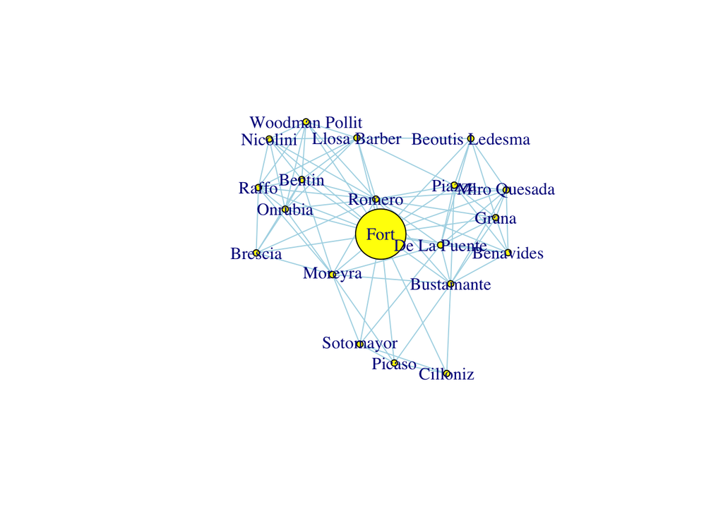

```r
egoSizes=rep(5,vcount(HubEgonet)) # sizes '5' for every node
egoSizes[hubix]=40  # size '40' for this one
V(HubEgonet)$size=egoSizes # saving sizes
plot.igraph(HubEgonet,
             vertex.color = 'yellow',
             edge.color='lightblue')
```

Can this network be disconnected? If so, we can compute the minimum number of nodes that must be removed to disconnect the network (create at least two components):

```r
vertex_connectivity(EliteNet_giant)
```

```
## [1] 1
```

Who is the sole node with the power to break the network?

```r
(cut=articulation_points(EliteNet_giant))
```

```
## + 1/28 vertex, named, from af6d51c:
## [1] Bentin
```

We can highlight the *articulation node* in the giant component:

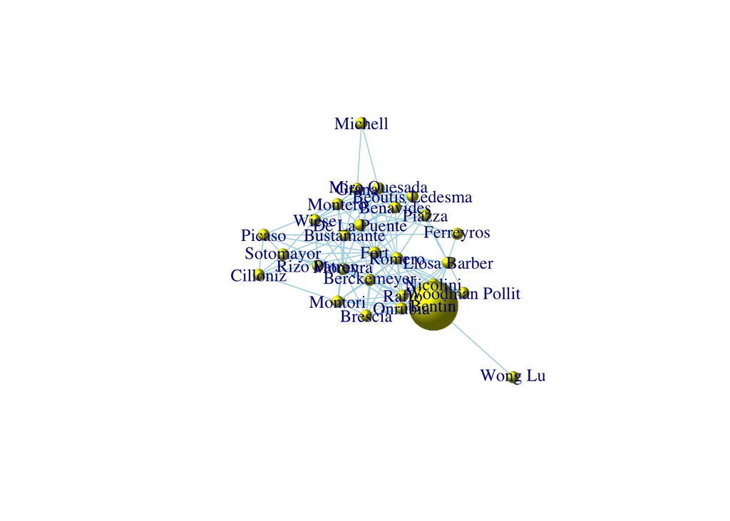

```r
cutix=which(V(EliteNet_giant)==cut)

allSizes=rep(10,vcount(EliteNet_giant))
allSizes[cutix]=40
V(EliteNet_giant)$size=allSizes # saving sizes
plot.igraph(EliteNet_giant,
             vertex.color = 'yellow',
             edge.color='lightblue',vertex.shape='sphere')
```

## Exporting the network

```r
write_graph(EliteNet, "EliteNetR.graphml", "graphml")
```

- [Go to Course schedule](https://evansdatascience.github.io/GovernanceAnalytics/)